# 2024-10-31-HTA-Minutes

## Minutes of HTA Working Group Meeting October 31, 2024

Minutes by Joseph Rickert (Note: this was the first general meeting of the working group.)

### Attendees

- Ursula Becker
- Gaizka Benguria
- Ian Bridges
- Tereza Burgetova
- Gregory Chen (Co -Chair & Founding Member)
- Natalie Dennis
- Katya Galactionova
- Abdul-Azeez Ganiyu
- Anders Gorst-Rasmussen (Co-chair & Founding Member)
- Jack Ettinger
- Frank
- Katie Harding
- Rob Hettle
- Rui Jin
- Denny John
- Mi Jun Keng
- Sven Klijn
- Lena
- Rongzhe Liu
- Maril Lorenzi
- Stephen McCawille
- Rebedda Metcaife
- Dominic Muston (Founding Member)
- Thuy Nhien
- Jay Park
- Thuin James Paul
- Chamath Perera
- Jep Poirrier
- Joseph Rickert (Founding Member)
- Pille Rinne
- Yevgeniy Samyshkin
- Robert Smith
- Karolin Struck
- Kristof T
- Lea Trela-larsen
- Jack Williams

The meeting was recorded and the video is available. Note that the meeting proper begins at **(10:22)** into the video.

A pdf file containing the meeting [presentation](https://github.com/RConsortium/HTA-wg/blob/main/Documents/RHTA%20meeting%20deck%2020241030.pdf) is also available at the [HTA GitHbub Repository](https://github.com/RConsortium/HTA-wg).

### Opening Remarks and Vision

**Video 10:22 to 19:05**

Co-chairs Gregory Chen and Anders Gorst-Rasmussen delivered the opening remarks and laid out the vision for the working group emphasizing that the working group is envisioned to be an industry-wide collaborative project. The two workstreams represent the initial thoughts of the founding members and are not “set in stone”.

[figure not shown]

### Workstream 1

**Video 19:05 to 24:45**

Anders-Gorst Rasmussen and Dominic Muston presented Workstream 1 which is about forging connections across the stakeholder landscape, cultivating a shared perspective, identifying the opportunities and the right problems to work on.

[figure not shown]

### Workshream 2

**Video 24:47 to 31:30**

Gregory Chen and Joseph Rickert presented workstream 2 which is focused on the practical goals of:

- Identifying and categorizing relevant R packages
- Curating those packages that are production ready and have sufficient documentation and quality.
- Being proactive in filling in gaps in documentation and elaborating on important use cases and promoting the use of R in HTA through blogs, webinars and other activities.

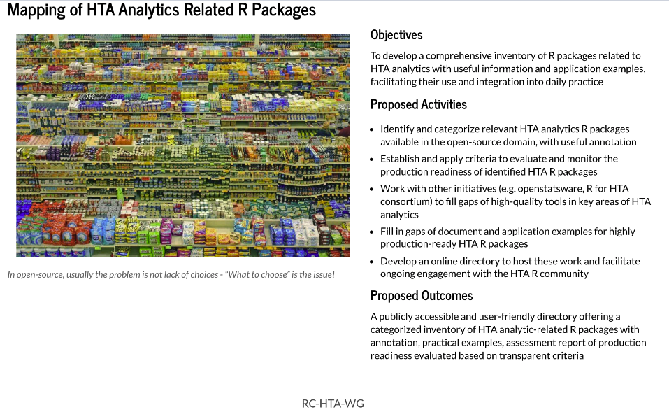

### Next Steps and How to Contribute

**Video 31:30 to 34:50**

- The GitHub repository https://github.com/RConsortium/HTA-wg is intended to be the central point for working group status and collaboration. You will find meeting minutes, working documents, discussions and relevant materials.
- Please update your comment on issue #1 that identifies you as a working group participant with a brief statement of your background
- Feel free to open up new issues to make suggestions, float ideas, highlight problems

### Group Discussion

**Video 34:51 to 1.02:14**

Several participants with different perspectives engaged in a collaborative discussion that covered several topics and contributed some great ideas on how to move forward. This section really got the working group off to a good start.

### Next Meeting

The next meeting of the HTA working group will be on Wednesday November 27, 2024 17:00 to 18:00 CET. You should already have an invitation to this meeting in you in-box. If not please open an issue in the GitHub repo or write to joseph.rickert@gmail.com